# STATS 101C: HW 7

Eric Chuu (604406828)

May 19, 2017

## **Exercise 7.9.9**

#### We use the variables $\texttt{dis}$ and $\texttt{nos}$ from the $\texttt{Boston}$ dataset, where $\texttt{dis}$ is the predictor, and $\texttt{nox}$ is the response.

#### (a) We first fit a cubic polynomial model to predict nox using dis. The summary output for the model shows that all three terms of the model (and the intercept) are significant. The plot of the fitted model is also shown below.

```r
# fit polynomial model of order 3 for: nox ~ dis
poly.fit = lm(nox ~ poly(dis, 3, raw = TRUE), data = b);

# summary of model
summary(poly.fit)
```

```
##
## Call:
## lm(formula = nox ~ poly(dis, 3, raw = TRUE), data = b)
##
## Residuals:
##       Min        1Q    Median        3Q       Max
## -0.121130 -0.040619 -0.009738  0.023385  0.194904
##
## Coefficients:
##                             Estimate Std. Error t value Pr(>|t|)
## (Intercept)                0.9341281  0.0207076  45.110  < 2e-16 ***
## poly(dis, 3, raw = TRUE)1 -0.1820817  0.0146973 -12.389  < 2e-16 ***
## poly(dis, 3, raw = TRUE)2  0.0219277  0.0029329   7.476 3.43e-13 ***
## poly(dis, 3, raw = TRUE)3 -0.0008850  0.0001727  -5.124 4.27e-07 ***
## ---
## Signif. codes:  0 '***' 0.001 '**' 0.01 '*' 0.05 '.' 0.1 ' ' 1
##
## Residual standard error: 0.06207 on 502 degrees of freedom
## Multiple R-squared:  0.7148, Adjusted R-squared:  0.7131
## F-statistic: 419.3 on 3 and 502 DF,  p-value: < 2.2e-16
```

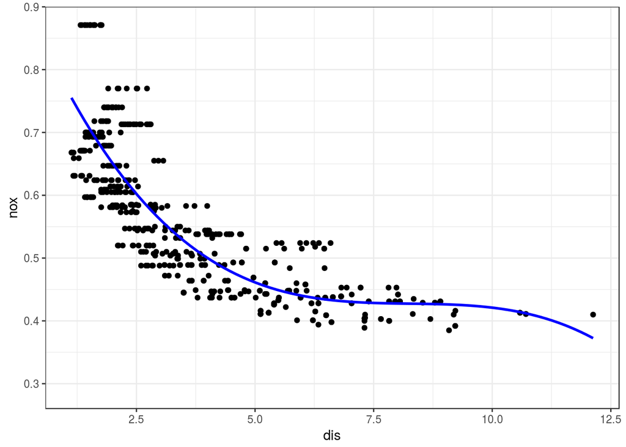

```r
# plot of resulting data
p1 = ggplot(b, aes(x = dis, y = nox)) + geom_point() + theme_bw()

p1 + stat_smooth(method = "lm", se = TRUE, fill = NA,
                formula = y ~ poly(x, 3, raw = TRUE), colour = "blue")
```

#### (d) We fit a regression spline to predict nox using dis. In general, we want the knots the be close to where there is more perturbation in data so that the model can capture more of the details/changes in those areas. In this case, there appears to be some changes in the overall trend of the data starting from dis = 6, so we indicate a knot at this point. The summary output of the model shows signifiance in all of the terms generated using the spline fit.

```r
# regression spline to predix nox using dis
spline.fit = lm(nox ~ bs(dis, df = 4, knots = c(6)), data = b)
summary(spline.fit)
```

```
##
## Call:
## lm(formula = nox ~ bs(dis, df = 4, knots = c(6)), data = b)
##
## Residuals:
##      Min       1Q   Median       3Q      Max
## -0.12387 -0.04012 -0.01033  0.02308  0.19446
##
## Coefficients:
##                                Estimate Std. Error t value Pr(>|t|)
## (Intercept)                     0.76037    0.01018  74.667  < 2e-16 ***
## bs(dis, df = 4, knots = c(6))1 -0.23672    0.02321 -10.200  < 2e-16 ***
## bs(dis, df = 4, knots = c(6))2 -0.36177    0.02548 -14.200  < 2e-16 ***
## bs(dis, df = 4, knots = c(6))3 -0.33337    0.04044  -8.244 1.47e-15 ***
## bs(dis, df = 4, knots = c(6))4 -0.36220    0.05105  -7.095 4.45e-12 ***
## ---
## Signif. codes:  0 '***' 0.001 '**' 0.01 '*' 0.05 '.' 0.1 ' ' 1
##
## Residual standard error: 0.06208 on 501 degrees of freedom
## Multiple R-squared:  0.7152, Adjusted R-squared:  0.7129
## F-statistic: 314.6 on 4 and 501 DF,  p-value: < 2.2e-16
```

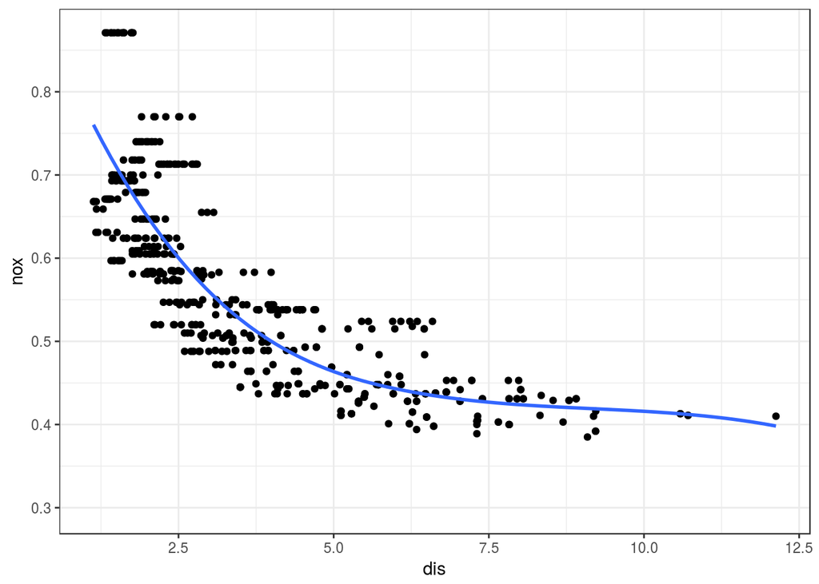

```r
p1 + stat_smooth(method = "lm", formula = y ~ bs(x, 4, knots = c(6)),
                 se = TRUE, fill = NA)
```

#### (e) Now, we fit a regression spine for a degrees of freedom ranging from 3 to 10. The RSS for each of the following fits is outputted and plotted below. We see that In general, as we increase the degrees of freedom, the RSS decreases. Each of the spline fits is also plotted on the same points to see the differences between the curves. We can see that with more degrees of freedom, the curves tend to have frequent local extrema, since they have flexibility to adapt to the data.

```r
rss = rep(0, 10)
colors = c("blue", "red", "green", "yellow", "seagreen2",
           "deeppink1", "purple", "sienna2", "orange", "slateblue1")
for (i in 3:10) {
    fit.i    = lm(nox ~ bs(dis, df = i), data = b)
    rss[i]   = sum(fit.i$residuals^2)
}

rss[3:10]
```

```
## [1] 1.934107 1.922775 1.840173 1.833966 1.829884 1.816995 1.825653 1.792535
```

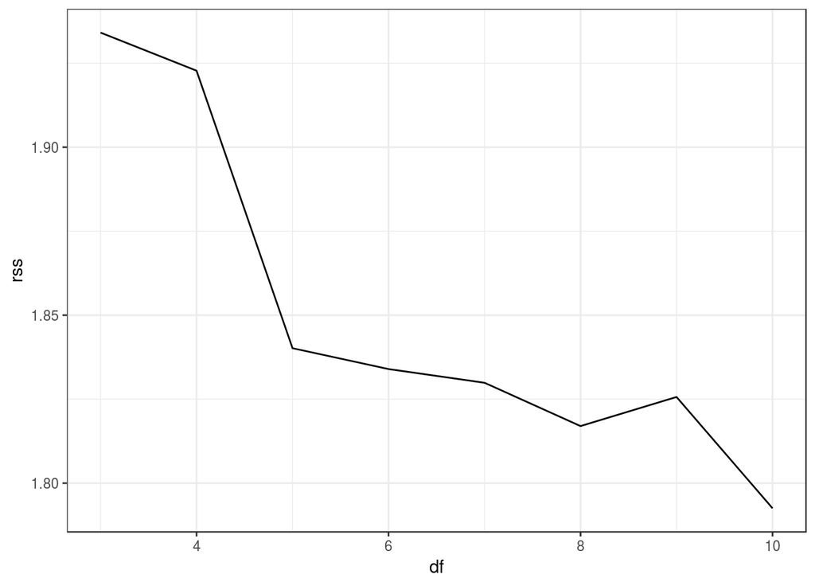

```r
df_rss = data.frame(df = 3:10, rss = rss[3:10])
ggplot(df_rss, aes(x = df, y = rss)) + geom_line() + theme_bw()
```

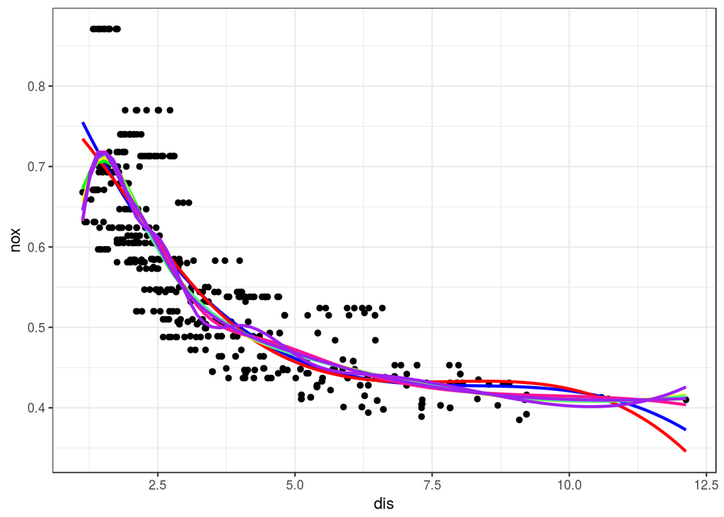

```r
p1 + stat_smooth(method = "lm", formula = y ~ bs(x, 3),
                 se = FALSE, fill = NA, colour = colors[1]) +
    stat_smooth(method = "lm", formula = y ~ bs(x, 4),
                 se = FALSE, fill = NA, colour = colors[2]) +
    stat_smooth(method = "lm", formula = y ~ bs(x, 5),
                 se = FALSE, fill = NA, colour = colors[3]) +
    stat_smooth(method = "lm", formula = y ~ bs(x, 6),
                 se = FALSE, fill = NA, colour = colors[4]) +
    stat_smooth(method = "lm", formula = y ~ bs(x, 7),
                 se = FALSE, fill = NA, colour = colors[5]) +
    stat_smooth(method = "lm", formula = y ~ bs(x, 8),
                 se = FALSE, fill = NA, colour = colors[6]) +
    stat_smooth(method = "lm", formula = y ~ bs(x, 9),
                 se = FALSE, fill = NA, colour = colors[7]) +
    stat_smooth(method = "lm", formula = y ~ bs(x, 10),
                se = FALSE, fill = NA, colour = colors[7])
```